# Support Vector Machine Analysis - Student Dropout Prediction

Early Warning System for Student Dropout Risk

2025-12-14

# Support Vector Machine Analysis

We will now test different vector models to understand what is the best classifier for our student’s performance. SVMs operate by identifying where the **margin** between different categories of data is the greatest. To classify our dataset, the model plots a separating line between the two outcome classes using a number of predictors - in order to keep it clear, we want to create a two-dimensional plane (two predictors).

By applying different kernels—linear, radial, and polynomial— we assess how the shape of the decision boundary affects prediction accuracy and determine which kernel provides the most reliable classification for our dataset.

## Feature Selection

For us to choose the best predictors, we will compute **F-statistic ANOVA** for every numeric feature in the dataset. The F-score tell us *how much* the mean of each feature differs between the **two target groups** (*Graduation*/*Dropout*). higher scores mean there is a bigger separation between classes, and a better cutoff between groups. Results indicate that grades and the amount of credits approved have the highest F-Values, suggesting they are the most significant predictors for predicting the success of graduating or not.

In this case, we want to choose the features of **second semester marks** and the **amount of units passed** to plot our model.

Top 5 Features by F-statistic

|  | Feature | F_value | p_value |
| --- | --- | --- | --- |
| 31 | Curricular.units.2nd.sem..approved. | 2711.44 | 0.000 |
| 32 | Curricular.units.2nd.sem..grade. | 2098.45 | 0.000 |
| 25 | Curricular.units.1st.sem..approved. | 1613.96 | 0.000 |
| 26 | Curricular.units.1st.sem..grade. | 1344.07 | 0.000 |
| 17 | Tuition.fees.up.to.date | 881.55 | 0.000 |

## Prepare Data for SVM

Support Vector Machines require **predictors** (numerical variables) and a **target** (categorical: *Graduate*/*Dropout*) for classification. The data was then structured into a format suitable for SVM modeling. The original dataset contained three academic outcomes: *Enrolled*, *Dropout*, and *Graduate*. Since the objective of this analysis is to distinguish students who ultimately graduate from those who drop out, **the Enrolled category was removed**. This reduces the dataset size but produces a cleaner binary classification.

Dataset Summary

| Metric | Value |
| --- | --- |
| Total Observations | 3630 |
| Target Classes | Dropout, Graduate |

## Train/Test Split

Now, we will split the data into training and testing sets, and then fit several SVM models to classify the students based on their marks.

Train/Test Split

| Dataset | Observations | Percentage |
| --- | --- | --- |
| Training | 2905 | 80% |
| Testing | 725 | 20% |

## Model Training

In our dataset, each student is described by academic features such as second-semester grades and credits passed. If the two groups—graduated and dropout— separate cleanly in a straight line, a linear SVM finds the optimal boundary that splits high-performing students from those with a higher risk of dropping out. But if the patterns are more complex, a non-linear kernel like the radial SVM transforms the data so the model can still draw a clear dividing boundary. This allows the SVM to classify students accurately even when the relationship between performance and graduation is not linear.

**Linear Kernel**: Creates a straight decision boundary to separate classes. This kernel is ideal when the data is linearly separable. In our student dropout analysis, a linear kernel would suggest that the relationship between academic performance metrics and graduation outcomes follows a straightforward, proportional pattern.

**Radial Basis Function (RBF) Kernel**: Generates curved, non-linear decision boundaries by measuring the distance between data points. This flexible kernel works best at tracking irregular patterns in the data. For our dataset, the RBF kernel can identify students who may succeed despite lower grades in one metric if they compensate with higher performance in another.

**Polynomial Kernel**: Produces curved boundaries with a specific degree of curve. In student performance prediction, a polynomial kernel might capture scenarios where moderate performance in both metrics leads to different outcomes than extreme performance in either direction, revealing threshold effects or interaction patterns between academic indicators.

## Model Evaluation

Predict and compare the models

### Linear Kernel Results

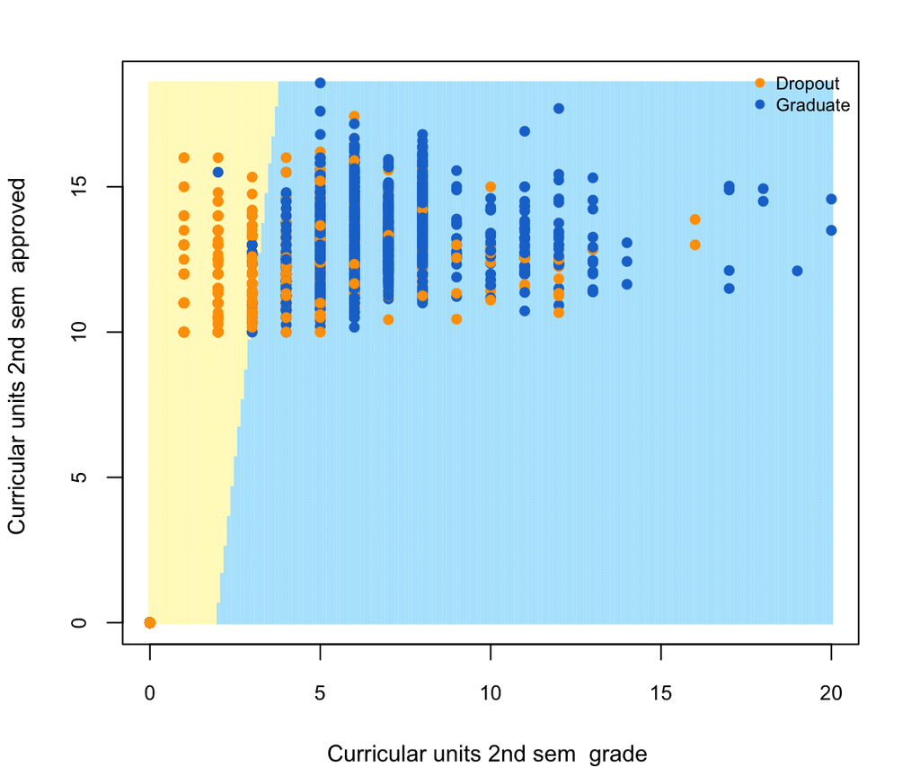

Linear Kernel - Confusion Matrix

|  | Dropout | Graduate |
| --- | --- | --- |
| Dropout | 218 | 25 |
| Graduate | 66 | 416 |

Linear Kernel - Performance Metrics

|  | Metric | Value |
| --- | --- | --- |
| Accuracy | Accuracy | 0.8745 |
| Sensitivity | Sensitivity | 0.7676 |
| Specificity | Specificity | 0.9433 |
| Kappa | Kappa | 0.7297 |

### Radial Kernel Results

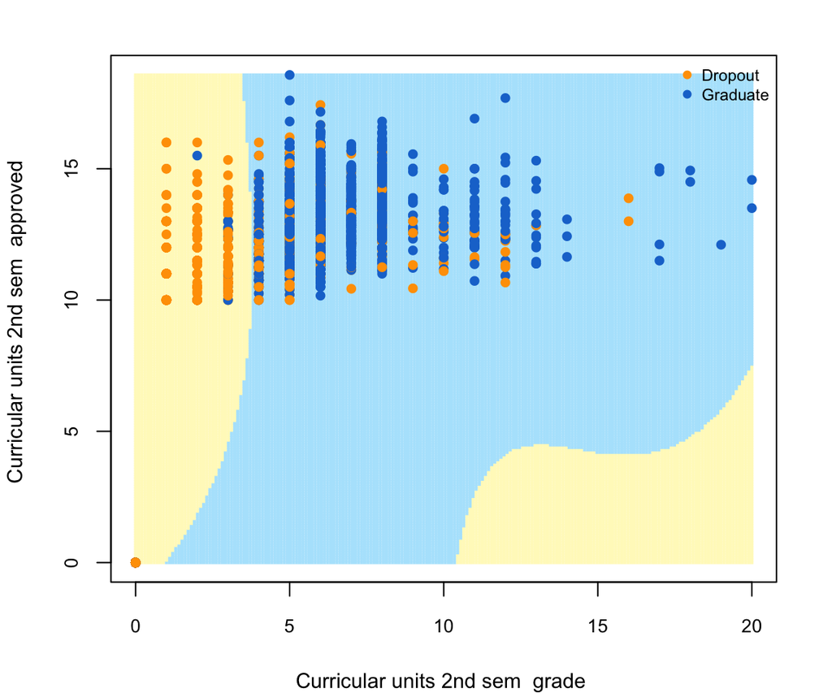

Radial Kernel - Confusion Matrix

|  | Dropout | Graduate |
| --- | --- | --- |
| Dropout | 220 | 25 |
| Graduate | 64 | 416 |

The radial kernel shows improved performance over the linear model, correctly classifying **220 dropouts** and **416 graduates**. The model reduced misclassifications of at-risk students, while maintaining the same **25 graduates misclassified as dropouts**. This suggests the **radial function better captures the relationships** in the data, leading to slightly better detection of students at risk of dropping out.

Radial Kernel - Performance Metrics

|  | Metric | Value |
| --- | --- | --- |
| Accuracy | Accuracy | 0.8772 |
| Sensitivity | Sensitivity | 0.7746 |
| Specificity | Specificity | 0.9433 |
| Kappa | Kappa | 0.7359 |

The radial kernel demonstrates a slight improvement in overall performance with an **accuracy of 87.7%** and **Kappa score of 0.7359**, both marginally better than the linear model. Notably, the **sensitivity increased to 77.46%**, showing improved ability to detect students at risk of dropping out. The **specificity holds steady at 94%**, maintaining excellent performance in identifying graduates. Overall, the radial kernel’s performance is quite similar to the linear model, suggesting that the relationship between the features may be linear.

### Polynomial Kernel Results

Polynomial Kernel - Confusion Matrix

|  | Dropout | Graduate |
| --- | --- | --- |
| Dropout | 186 | 17 |
| Graduate | 98 | 424 |

Polynomial Kernel - Performance Metrics

|  | Metric | Value |
| --- | --- | --- |
| Accuracy | Accuracy | 0.8414 |
| Sensitivity | Sensitivity | 0.6549 |
| Specificity | Specificity | 0.9615 |
| Kappa | Kappa | 0.6493 |

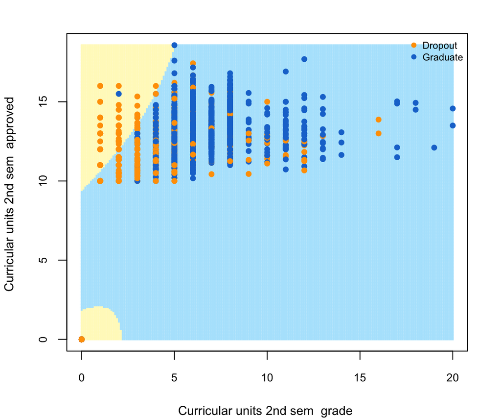

## Performance Comparison

After evaluating all three SVM kernels, the results show minimal performance differences across models. The **radial kernel** achieved the highest accuracy at 87.7%, followed closely by the **linear kernel** at 87.4%, while the **polynomial kernel** performed slightly lower at 84.1%. However, given the marginal improvement of only 0.3% between the linear and radial models, the **linear kernel is the preferred choice** for this classification task. It offers comparable predictive performance while maintaining greater interpretability and computational efficiency—critical factors when deploying models in educational settings where stakeholders need to understand and trust the decision-making process. The linear model’s simplicity also makes it easier to explain to administrators and educators, making interventions for at-risk students without sacrificing meaningful accuracy.

Model Accuracy Comparison

| Model | Accuracy |
| --- | --- |
| Linear | 0.874 |
| Radial | 0.877 |
| Polynomial | 0.841 |